# Lecture 09 - Preprocessing & Feature Engineering/Selection Part 1

ANLY 530- Machine Learning

2023-10-25

# Outline

- Pre-Processing Data
  - Subsetting Ignoble Variables
  - Missing Data
  - Outliers
  - Normalization
- Feature Selection
  - Correlation
  - Variable Importance

# Pre-processing Data

- Before feature engineering/selection or modeling it is important to clean the data.

**“Garbage In Garbage Out”**

# Subset Ignoble Variables

- You are not always going to need every variable in the original dataset.
- Simply remove any variable you will not need from the data.
- The method will change depending on the programming language.

# Subset Variables in Python

```python
from sklearn.datasets import load_iris
import pandas as pd
import numpy as np
iris = load_iris()
df = pd.DataFrame(data= np.c_[iris['data'], iris['target']],
                  columns= iris['feature_names'] + ['Species'])
df = df[['sepal width (cm)','petal length (cm)','petal width (cm)','Species']]
print(df.head())
```

```
##    sepal width (cm)  petal length (cm)  petal width (cm)  Species
## 0               3.5                1.4               0.2      0.0
## 1               3.0                1.4               0.2      0.0
## 2               3.2                1.3               0.2      0.0
## 3               3.1                1.5               0.2      0.0
## 4               3.6                1.4               0.2      0.0
```

# Subset Variables in R

```r
library(datasets)
data(iris)
data = iris
remove = c("Petal.Width")
data = data[, !colnames(data) %in% c(remove)]
print(str(data))
```

```
## 'data.frame':    150 obs. of  4 variables:
##  $ Sepal.Length: num  5.1 4.9 4.7 4.6 5 5.4 4.6 5 4.4 4.9 ...
##  $ Sepal.Width : num  3.5 3 3.2 3.1 3.6 3.9 3.4 3.4 2.9 3.1 ...
##  $ Petal.Length: num  1.4 1.4 1.3 1.5 1.4 1.7 1.4 1.5 1.4 1.5 ...
##  $ Species     : Factor w/ 3 levels "setosa","versicolor",..: 1 1 1 1 1 1 1 1 1 1 ...
## NULL
```

- Another method is to build a function:

```r
subset_var <- function(x,y){
  remove = c(toString(y))
  sub = x[, !colnames(x) %in% c(remove)]
  return(str(sub))
}
subset_var(data,'Petal.Width')
```

```
## 'data.frame':    150 obs. of  4 variables:
##  $ Sepal.Length: num  5.1 4.9 4.7 4.6 5 5.4 4.6 5 4.4 4.9 ...
##  $ Sepal.Width : num  3.5 3 3.2 3.1 3.6 3.9 3.4 3.4 2.9 3.1 ...
##  $ Petal.Length: num  1.4 1.4 1.3 1.5 1.4 1.7 1.4 1.5 1.4 1.5 ...
##  $ Species     : Factor w/ 3 levels "setosa","versicolor",..: 1 1 1 1 1 1 1 1 1 1 ...
```

# Missing Data in Python

- Imputing data is one of the easiest methods to deal with missing values and NA values.
- You should save the dataset after changing it from the original. You never know when you’ll need it again.

```python
from sklearn.datasets import load_iris
iris = load_iris()
import pandas as pd
import numpy as np
df = pd.DataFrame(data= np.c_[iris['data'], iris['target']],
                  columns= iris['feature_names'] + ['Species'])
```

- Lets use the mean to replace missing and NA values.

```python
missing_col = ['sepal length (cm)']
for i in missing_col:
 df.loc[df.loc[:,i].isnull(),i]=df.loc[:,i].mean()
```

- Looping through the columns.

```python
names = list(df.columns)
rang = range(0,len(names))
for i in rang:
  missing_col = [names[i]]
  for i in missing_col:
    df.loc[df.loc[:,i].isnull(),i]=df.loc[:,i].mean()
```

# Missing Data in R

```r
library(datasets)
data(iris)
data = iris
if (!require("mice")) {
  install.packages("mice")
  library(mice)
}
if (!require("magrittr")) {
  install.packages("magrittr")
  library(magrittr)
}
missing = data %>% mice::mice(m=5,maxit=50,meth="sample",seed=500,print = FALSE)
missing <- mice::complete(missing, action=as.numeric(2))
data = na.omit(missing)
write.csv(data,"data/data.csv")
print(str(data))
```

```
## 'data.frame':    150 obs. of  5 variables:
##  $ Sepal.Length: num  5.1 4.9 4.7 4.6 5 5.4 4.6 5 4.4 4.9 ...
##  $ Sepal.Width : num  3.5 3 3.2 3.1 3.6 3.9 3.4 3.4 2.9 3.1 ...
##  $ Petal.Length: num  1.4 1.4 1.3 1.5 1.4 1.7 1.4 1.5 1.4 1.5 ...
##  $ Petal.Width : num  0.2 0.2 0.2 0.2 0.2 0.4 0.3 0.2 0.2 0.1 ...
##  $ Species     : Factor w/ 3 levels "setosa","versicolor",..: 1 1 1 1 1 1 1 1 1 1 ...
## NULL
```

# Outliers in Python

```python
from sklearn.datasets import load_iris
iris = load_iris()
import pandas as pd
import numpy as np
df = pd.DataFrame(data= np.c_[iris['data'], iris['target']],
                  columns= iris['feature_names'] + ['Species'])
```

- We will use the median to replace the outliers in the data.

```python
names = list(df.columns)
rang = range(0,len(names))
for i in rang:
  missing_col = [names[i]]
  median = float(df[missing_col].median())
  df[missing_col] = np.where(df[missing_col] > median, median, df[missing_col])
```

# Outliers in R

```r
library(datasets)
data(iris)
data = iris
if (!require("outlieR")) {
  remotes::install_github("rushkin/outlieR")
  library(outlieR)
}
if (!require("magrittr")) {
  install.packages("magrittr")
  library(magrittr)
}
data = data[,-c(5)]
data = data %>% outlieR::impute(flag = NULL, fill = "mean",
                                level = 0.1, nmax = NULL,
                                side = NULL, crit = "lof",
                                k = 5, metric = "euclidean", q = 3)
data = data.frame(cbind(data,"Species" = iris$Species))
print(str(data))
```

```
## 'data.frame':    150 obs. of  5 variables:
##  $ Sepal.Length: num  5.1 4.9 4.7 4.6 5 5.4 4.6 5 4.4 4.9 ...
##  $ Sepal.Width : num  3.5 3 3.2 3.1 3.6 3.9 3.4 3.4 2.9 3.1 ...
##  $ Petal.Length: num  1.4 1.4 1.3 1.5 1.4 1.7 1.4 1.5 1.4 1.5 ...
##  $ Petal.Width : num  0.2 0.2 0.2 0.2 0.2 0.4 0.3 0.2 0.2 0.1 ...
##  $ Species     : Factor w/ 3 levels "setosa","versicolor",..: 1 1 1 1 1 1 1 1 1 1 ...
## NULL
```

# Normalization in Python

- Ignore the target variable, you do not want to normalize it.

```python
import pandas as pd
from sklearn import datasets
import numpy as np
iris = datasets.load_iris()
X = iris.data
from sklearn.preprocessing import scale
x = scale(X)
```

# Normalization in R

- The `preProcess` function does nto ignore the target variable if it is numerical, only if it is factor type.
- Otherwise you would have to subset the target out and add it back into the frame after normalizing the inputs.

```r
library(datasets)
data(iris)
data = iris
if (!require('caret')) {
  install.packages("caret", dependencies = TRUE)
  library(caret)
}
if (!require('magrittr')) {
  install.packages("magrittr", dependencies = TRUE)
  library(magrittr)
}
preProClean <- preProcess(x = data, method = c("scale", "center"))
data <- predict(preProClean, data %>% na.omit)
print(str(data))
```

```
## 'data.frame':    150 obs. of  5 variables:
##  $ Sepal.Length: num  -0.898 -1.139 -1.381 -1.501 -1.018 ...
##  $ Sepal.Width : num  1.0156 -0.1315 0.3273 0.0979 1.245 ...
##  $ Petal.Length: num  -1.34 -1.34 -1.39 -1.28 -1.34 ...
##  $ Petal.Width : num  -1.31 -1.31 -1.31 -1.31 -1.31 ...
##  $ Species     : Factor w/ 3 levels "setosa","versicolor",..: 1 1 1 1 1 1 1 1 1 1 ...
## NULL
```

# Feature Selection

- We will discuss two very easy techniques to master in-order to select features to model with including:
  1. Correlation
  2. Variable Importance
- We will ignore an empirical method as it is very time and computationally intensive and not the best method to deploy for feature selection.

# Correlation Selection in Python

```python
iris = load_iris()
data = pd.DataFrame(data= np.c_[iris['data'], iris['target']],
                  columns= iris['feature_names'] + ['Species'])
corr = data.corr()
print(corr)
```

```
##                    sepal length (cm)  ...   Species
## sepal length (cm)           1.000000  ...  0.782561
## sepal width (cm)           -0.117570  ... -0.426658
## petal length (cm)           0.871754  ...  0.949035
## petal width (cm)            0.817941  ...  0.956547
## Species                     0.782561  ...  1.000000
##
## [5 rows x 5 columns]
```

# Correlation Selection in R

- Simply identify a variables that are highly correlated and remove one of them from the dataset.
- You may even remove one and try modeling and then remove the other and try modeling.

```r
library(datasets)
data(iris)
data = iris
cor = cor(data[,c(1:4)])
print(cor)
```

```
##              Sepal.Length Sepal.Width Petal.Length Petal.Width
## Sepal.Length    1.0000000  -0.1175698    0.8717538   0.8179411
## Sepal.Width    -0.1175698   1.0000000   -0.4284401  -0.3661259
## Petal.Length    0.8717538  -0.4284401    1.0000000   0.9628654
## Petal.Width     0.8179411  -0.3661259    0.9628654   1.0000000
```

# Variable Importance

- To capture the importance of a variable we must actually build a ml model, train it, and used the trained state to provide the importance measures for each feature.
- Depending on regression or classification type problem may impact the model technique utilized.
- A best practice would be to train multiple models and compare the importance of the features within each trained model, which provides a more comprehensive and generalized look at what features to include in your real modeling.

# Variable Importance in Python for Classification

- We will build and train 3 classifiers including:
  - Decision Tree
  - Random Forest
  - Logistic Regression
- Each model will be built/trained using the `sklearn` architecture.

```python
import sklearn
```

# Load a Dataset

```python
from sklearn.datasets import load_iris
iris = load_iris()
X = pd.DataFrame(iris.data, columns=iris.feature_names)
y = iris.target
```

# Train each of the Models

```python
from sklearn.tree import DecisionTreeClassifier
from sklearn.ensemble import RandomForestClassifier
from sklearn.linear_model import LogisticRegression
dt = DecisionTreeClassifier()
dt.fit(X, y)
```

```
## DecisionTreeClassifier()
```

```python
rf = RandomForestClassifier()
rf.fit(X, y)
```

```
## RandomForestClassifier()
```

```python
lr = LogisticRegression()
lr.fit(X, y)
```

[output not shown]

# Capture the Variable Importance of each Model

```python
importance = dt.feature_importances_
for i,v in enumerate(importance):
    print('Feature: %0d, Score: %.5f' % (i,v))
```

```
## Feature: 0, Score: 0.00000
## Feature: 1, Score: 0.01333
## Feature: 2, Score: 0.06406
## Feature: 3, Score: 0.92261
```

```python
importance = rf.feature_importances_
for i,v in enumerate(importance):
    print('Feature: %0d, Score: %.5f' % (i,v))
```

```
## Feature: 0, Score: 0.11113
## Feature: 1, Score: 0.02826
## Feature: 2, Score: 0.41623
## Feature: 3, Score: 0.44438
```

```python
importance = lr.coef_[0]
for i,v in enumerate(importance):
    print('Feature: %0d, Score: %.5f' % (i,v))
```

```
## Feature: 0, Score: -0.41813
## Feature: 1, Score: 0.96633
## Feature: 2, Score: -2.52103
## Feature: 3, Score: -1.08410
```

# Variable Importance in R for Classification

```r
library(caret)
```

# Load a Dataset

```r
library(datasets)
data("iris")
iris = iris
str(iris)
```

```
## 'data.frame':    150 obs. of  5 variables:
##  $ Sepal.Length: num  5.1 4.9 4.7 4.6 5 5.4 4.6 5 4.4 4.9 ...
##  $ Sepal.Width : num  3.5 3 3.2 3.1 3.6 3.9 3.4 3.4 2.9 3.1 ...
##  $ Petal.Length: num  1.4 1.4 1.3 1.5 1.4 1.7 1.4 1.5 1.4 1.5 ...
##  $ Petal.Width : num  0.2 0.2 0.2 0.2 0.2 0.4 0.3 0.2 0.2 0.1 ...
##  $ Species     : Factor w/ 3 levels "setosa","versicolor",..: 1 1 1 1 1 1 1 1 1 1 ...
```

# Setup the Test Harnesses

```r
control <- trainControl(method="cv", number=10)
metric <- "Accuracy"
set.seed(7)
```

# Train each of the Models

```r
fit.rpart <- train(Species~., data = iris, method="rpart", metric=metric, trControl=control)
fit.rf <- train(Species~., data = iris, method="rf", metric=metric, trControl=control)
fit.nb <- train(Species~., data = iris, method="naive_bayes", metric=metric, trControl=control)
```

# Capture the Variable Importance of Each Model

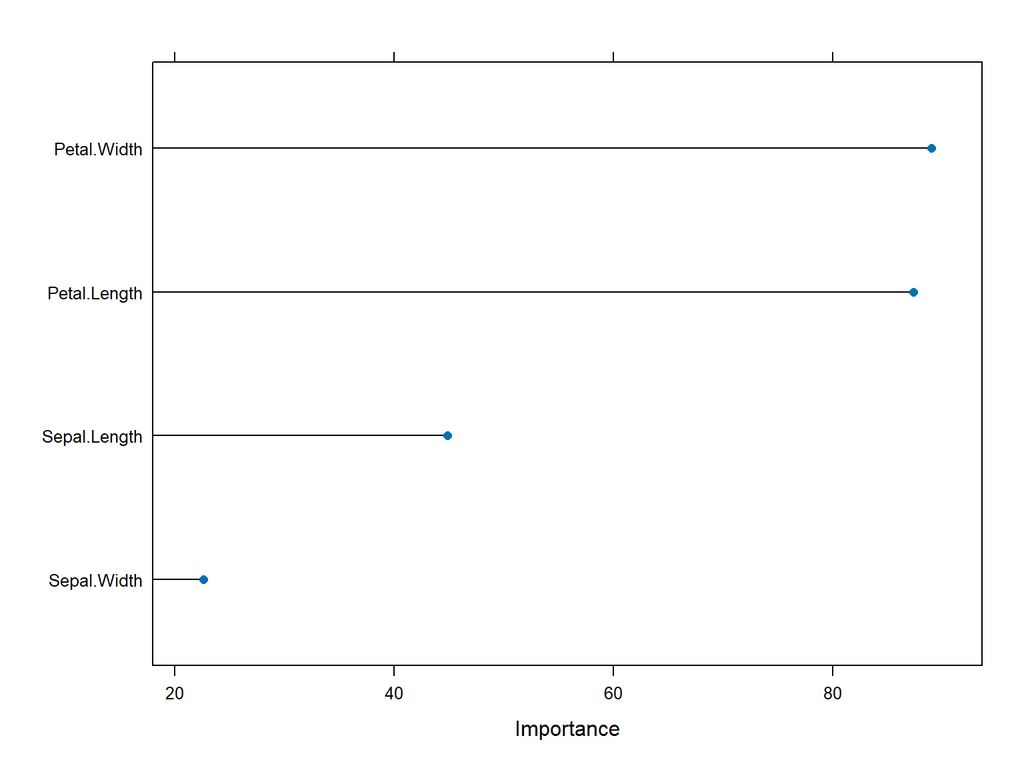

```r
vi = varImp(fit.rpart, scale = FALSE)
plot(vi, top = ncol(iris)-1)
```

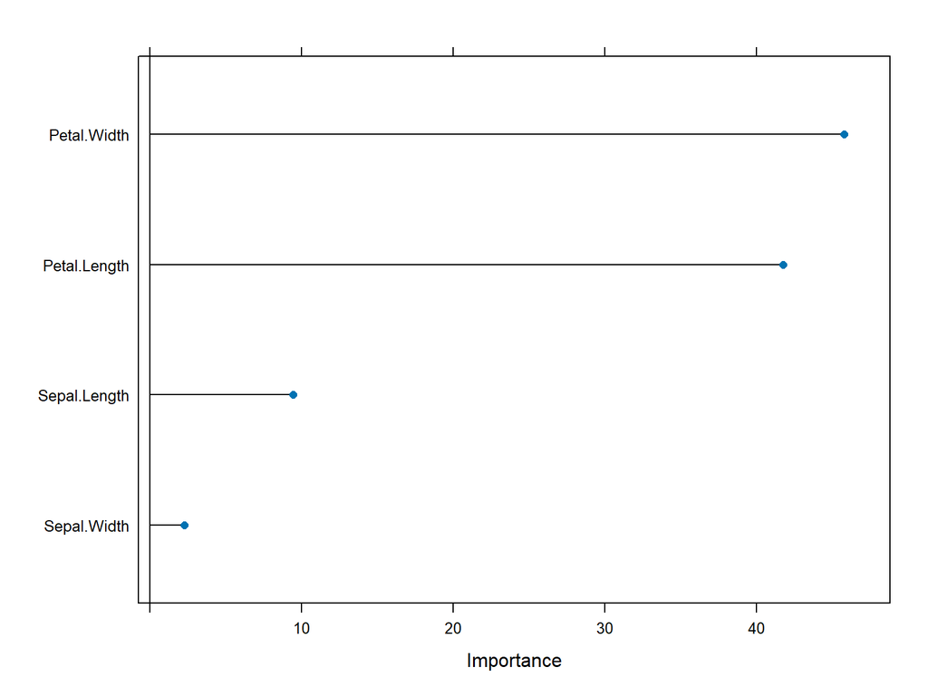

```r
vi = varImp(fit.rf, scale = FALSE)
plot(vi, top = ncol(iris)-1)
```

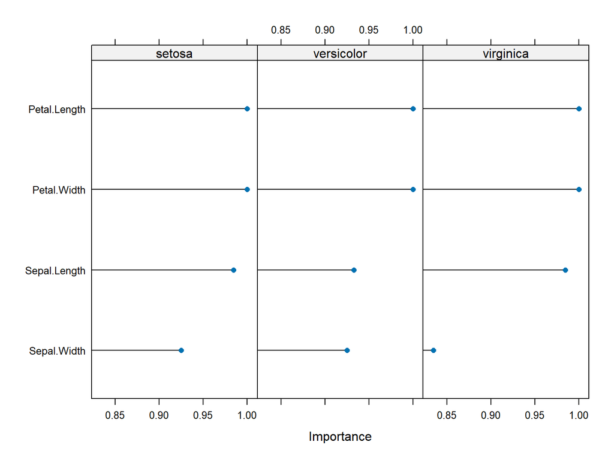

```r
vi = varImp(fit.nb, scale = FALSE)
plot(vi, top = ncol(iris)-1)
```

# Variable Importance in R for Regression

```r
library(caret)
```

# Load a Dataset

```r
library(quantmod)
library(TTR)
start <- as.Date(Sys.Date()-(365*5))
end <- as.Date(Sys.Date())
getSymbols("DEXJPUS",src="FRED", from = start, to = end)
```

```
## [1] "DEXJPUS"
```

```r
data = na.omit(DEXJPUS)
colnames(data) = c("Close")
sma_1 = SMA(data$Close, n = 48)
sma_2 = SMA(data$Close, n = 96)
sma_3 = SMA(data$Close, n = 144)
data = data.frame(sma_1 = sma_1, sma_2 = sma_2, sma_3 = sma_3, close = data$Close)
data = na.omit(data)
str(data)
```

```
## 'data.frame':    1099 obs. of  4 variables:
##  $ SMA  : num  111 111 111 111 111 ...
##  $ SMA.1: num  111 111 111 111 111 ...
##  $ SMA.2: num  111 111 111 111 111 ...
##  $ Close: num  110 109 108 108 108 ...
##  - attr(*, "na.action")= 'omit' Named int [1:143] 1 2 3 4 5 6 7 8 9 10 ...
##   ..- attr(*, "names")= chr [1:143] "2018-10-26" "2018-10-29" "2018-10-30" "2018-10-31" ...
```

# Setup the Test Harnesses

```r
control <- trainControl(method="cv", number=10)
metric <- "RMSE"
set.seed(7)
```

# Train each of the Models

```r
fit.lm <- train(Close~., data = data, method="lm", metric=metric, trControl=control)
fit.rf <- train(Close~., data = data, method="rf", metric=metric, trControl=control)
fit.dt <- train(Close~., data = data, method="rpart", metric=metric, trControl=control)
```

# Capture the Variable Importance of Each Model

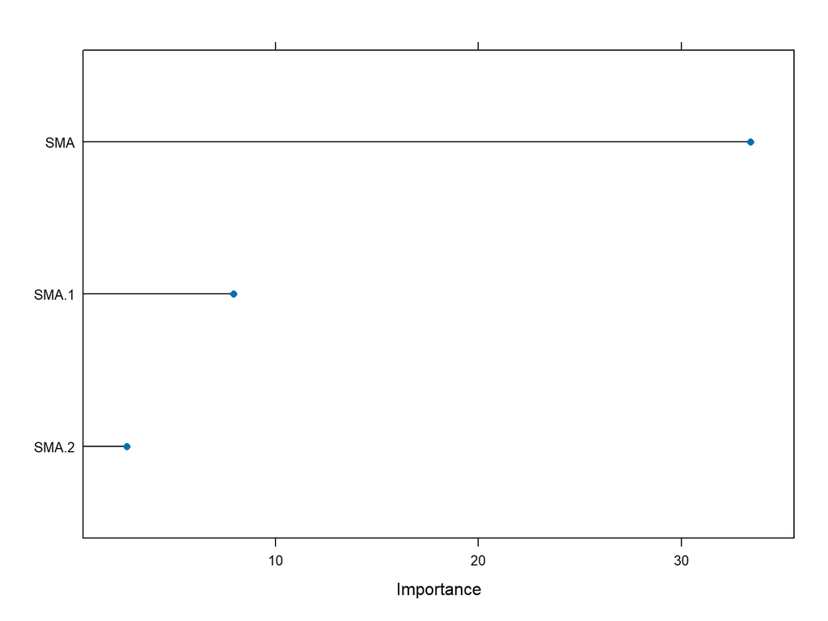

```r
vi = varImp(fit.lm, scale = FALSE)
plot(vi, top = ncol(data)-1)
```

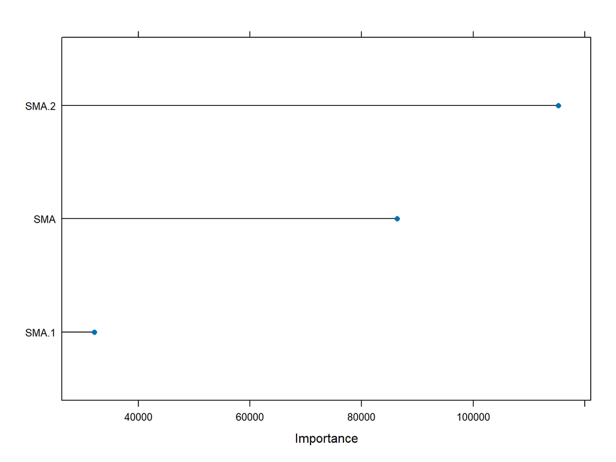

```r
vi = varImp(fit.rf, scale = FALSE)
plot(vi, top = ncol(data)-1)
```

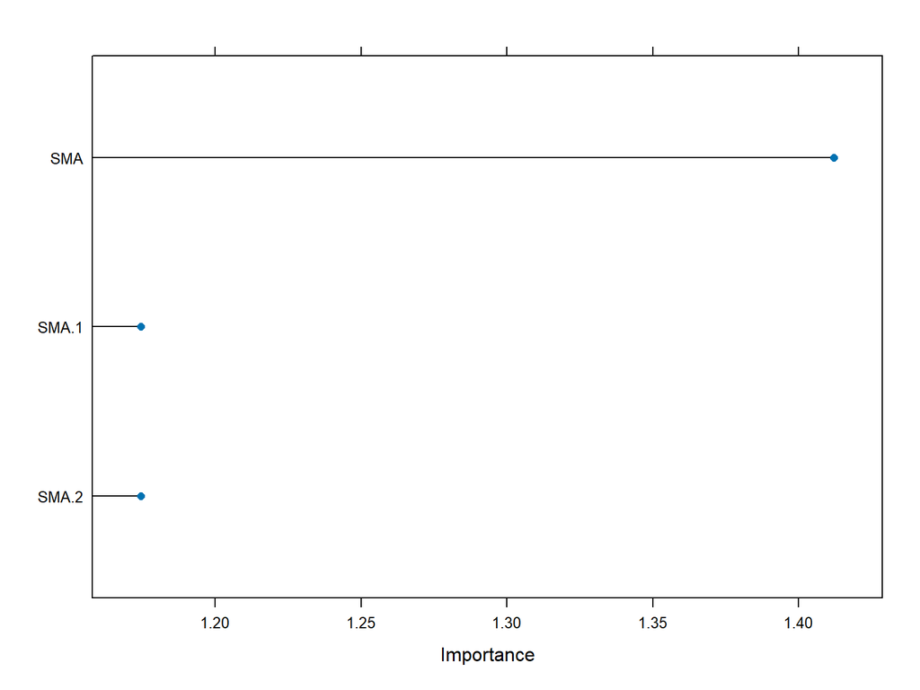

```r
vi = varImp(fit.dt, scale = FALSE)
plot(vi, top = ncol(data)-1)
```